```r
#necessary_library
library(dplyr)
```

```r
library(highcharter)
library(tidyverse)
library(RColorBrewer)
library(pacman)
library(ggplot2)
library(treemapify)
library(ggpubr)

#opening survery data file
survey_data <- read.csv(file.choose())
survey_schema  <- read.csv(file.choose())

#Finding all the countries with respondents

total_countries <- survey_data %>%
  group_by(Country)%>%
  summarise(Number=n())%>%
  arrange(desc=Number)%>%
  ungroup()%>%
  mutate(Country = reorder(Country, Number))%>%
  select(Country, Number)
#Finding the countries with top respondents
top_countries <- survey_data %>%
  group_by(Country)%>%
  summarise(Number=n())%>%
  arrange(desc=Number)%>%
  ungroup()%>%
  mutate(Country = reorder(Country, Number))%>%
  top_n(20, wt = Number)
# Load the world Map data
data(worldgeojson, package = "highcharter")

total_countries_plot <- highchart() %>%
  hc_add_series_map(
    worldgeojson, total_countries, value = "Number", joinBy = c('name','Country'),
    name = "Number of Respondents"
  )  %>%
  hc_colorAxis(stops = color_stops()) %>%
  hc_title(text = "World Map") %>%
  hc_subtitle(text = "Total respondent country in 2020")
#plotting the treemap

colourCount = length(unique(top_countries$Country)) #get the unique color
getPalette = colorRampPalette(brewer.pal(9, "PuOr")) #choose the color palette

#visualize using ggplot
```

## TreeMap from top 20 Countries with most respondents

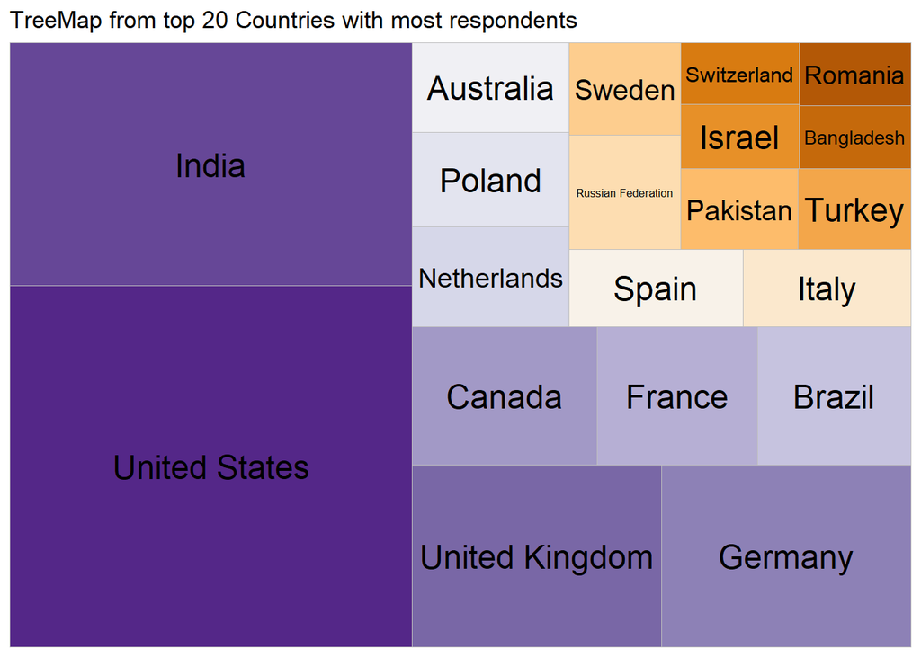

```r
#visualize using ggplot
ggplot(top_countries, aes(area=Number, fill=factor(Country), label=Country))+
  geom_treemap(show.legend=F) +
  geom_treemap_text(color="black", place="centre") +
  scale_fill_manual(values=getPalette(colourCount)) + labs(title="TreeMap from top 20 Countries with most respondents")
```

## Barplot of responses according to country

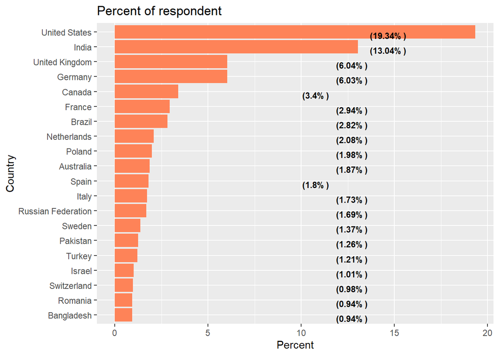

```r
options(repr.plot.width=9, repr.plot.height=6) #setting height and width of the plot
fillcolor1 <- "#FE8358"
fillcolor2 <- "#F1FB92"
line.length <- nrow(survey_data)

percentage_topcountries <- survey_data %>%
  group_by(Country) %>%
  summarise(Counting=round(n()/line.length * 100, 2)) %>%
  arrange(desc(Counting)) %>%
  ungroup() %>%
  mutate(country = reorder(Country, Counting)) %>%
  head(20)
percentage_topcountries_plot <- ggplot(percentage_topcountries, aes(x = country, y = Counting)) +
  geom_bar(stat = "identity", fill = fillcolor1)+
  geom_text(aes(x = Country, y = 0.01, label = paste0("(", Counting, "% )", sep = "")),
            hjust = -7, vjust = 1, size = 3, color = "black", fontface = "bold")+
  scale_y_continuous()+
  labs(x = "Country", y = "Percent", title = "Percent of respondent")+
  coord_flip()
percentage_topcountries_plot
```

## developer by profession question response world plot

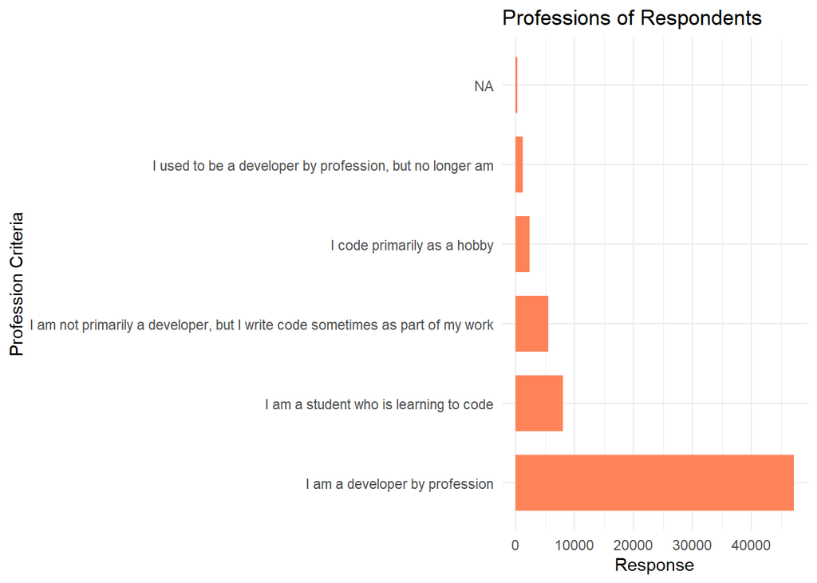

```r
counting_developer_by_branch <- survey_data %>%
  filter(!is.na(MainBranch)) %>%
  group_by(MainBranch) %>%
  count()
ggplot(survey_data,aes(y=factor(MainBranch)))+
  geom_bar(stat="count", width=0.7, fill=fillcolor1)+
  labs(title= "Professions of Respondents",
       y="Profession Criteria",
       x="Response") + theme_minimal()
```

## coding as hobby question world plot

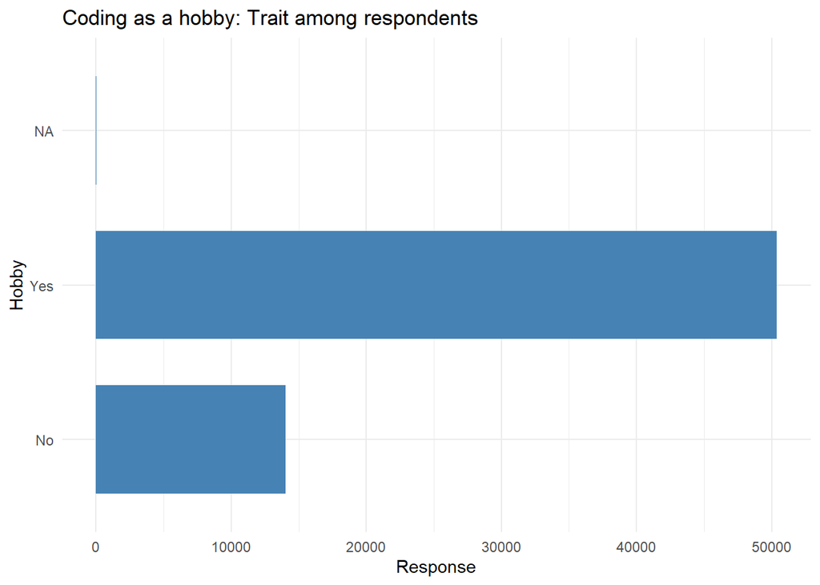

```r
ggplot(survey_data,aes(y=factor(Hobbyist)))+  geom_bar(stat="count", width=0.7, fill="steelblue")+
  labs(title= "Coding as a hobby: Trait among respondents",
       y="Hobby",
       x="Response") + theme_minimal()
```

```r
##Finding employment Type
employment_type <- survey_data %>%
  filter(!is.na(Employment)) %>%
  group_by(Employment) %>%
  count()
```

## Female to Male Ration - Better Countries

```r
Female_male_ratio_plot <- survey_data %>%
  group_by(Country) %>%
  mutate(count = n()) %>%
  filter(count > 200) %>%
  filter(Gender %in% c('Man', 'Woman')) %>%
  group_by(Country, Gender) %>%
  count() %>%
  spread(Gender,n) %>%
  mutate(Female_to_male_ratio = Woman / Man) %>%
  arrange(desc(Female_to_male_ratio)) %>%
  head(50) %>%
  hchart('column', hcaes(x = 'Country', y = 'Female_to_male_ratio')) %>%
  hc_title(text = "Top 50 countries ordered with better female to male ratio") %>%
  hc_colors(c("steelblue", "darkgray")) %>%
  hc_xAxis(title = list(text = "Countries"))
Female_male_ratio_plot
```

[interactive chart not shown]

## Male-female ratio among respondents

```r
male_female_percentage <- survey_data %>%
  filter(!is.na(Gender)) %>%
  select(Gender) %>%
  mutate(Gender = str_split(Gender, pattern = ";")) %>%
  unnest(Gender) %>%
  group_by(Gender) %>%
  summarise(Count = n()) %>%
  arrange(desc(Count)) %>%
  mutate(percentage = round((Count/sum(Count))*100)) %>%
  arrange(desc(percentage))
```

## Which of the following best describes your main field of study (aka 'major')?

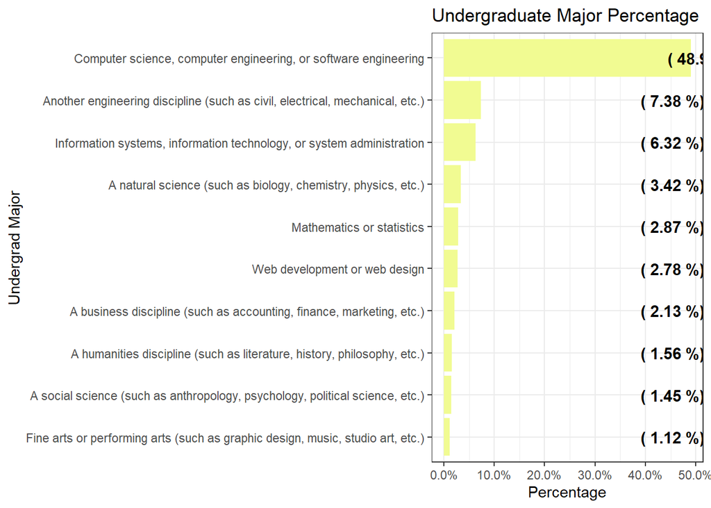

```r
TotalNoofRows <- nrow(survey_data)
plotUndergradEducation <- function(survey_data, TotalNoofRows)
{
  survey_data %>%
    filter(!is.na(survey_data$UndergradMajor)) %>%
    select(UndergradMajor) %>%
    group_by(UndergradMajor) %>%
    summarise(Count = n()/TotalNoofRows) %>%
    arrange(desc(Count)) %>%
    ungroup() %>%
    mutate(UndergradMajor = reorder(UndergradMajor,Count)) %>%
    head(10) %>%
    ggplot(aes(x = UndergradMajor, y = Count))+
    geom_bar(stat = 'identity', fill = fillcolor2)+
    geom_text(aes(x = UndergradMajor,y = .01, label = paste0("( ",round(Count*100,2)," %)",sep="")),
              hjust = -3, vjust = .5, size= 4, color = 'black', fontface = 'bold')+
    scale_y_continuous(labels = scales::percent_format()) +
    labs(
      x = 'Undergrad Major',
      y = 'Percentage',
      title = 'Undergraduate Major Percentage'
    )+
    coord_flip()+
    theme_bw()
}
plotUndergradEducation(survey_data, TotalNoofRows)
```

# Developer Desire Next Year ## Platform Desire Next Year

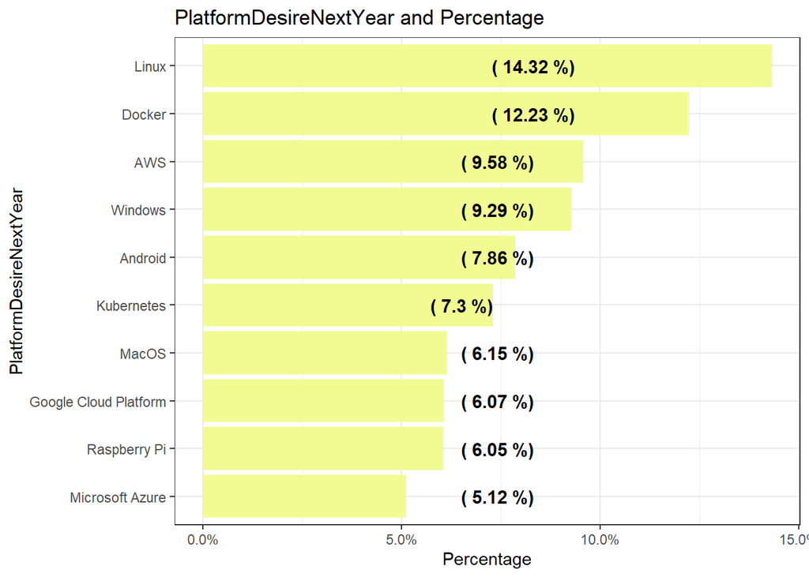

```r
plotPlatformDesire <- function(survey_data,TotalNoofRows) {
  survey_data %>%
    filter(!is.na(PlatformDesireNextYear)) %>%
    select(PlatformDesireNextYear) %>%
    mutate(PlatformDesireNextYear = str_split(PlatformDesireNextYear, pattern = ";")) %>%
    unnest(PlatformDesireNextYear) %>%
    group_by(PlatformDesireNextYear) %>%
    summarise(Count = n()) %>%
    arrange(desc(Count)) %>%
    ungroup() %>%
    mutate(TotalCount =  sum(Count)) %>%
    mutate(Count =  Count/TotalCount) %>%
    mutate(PlatformDesireNextYear = reorder(PlatformDesireNextYear,Count)) %>%
    head(10) %>%

    ggplot(aes(x = PlatformDesireNextYear,y = Count)) +
    geom_bar(stat='identity',fill= fillcolor2) +
    geom_text(aes(x = PlatformDesireNextYear,y = .01, label = paste0("( ",round(Count*100,2)," %)",sep="")),
              hjust= -3, vjust=.5, size = 4, colour = 'black',
              fontface = 'bold') +
    scale_y_continuous(labels = scales::percent_format()) +
    labs(x = 'PlatformDesireNextYear',
         y='Percentage',
         title = 'PlatformDesireNextYear and Percentage') +
    coord_flip() +
    theme_bw()
}
plotPlatformDesire(survey_data,TotalNoofRows)
```

##Language worked with this

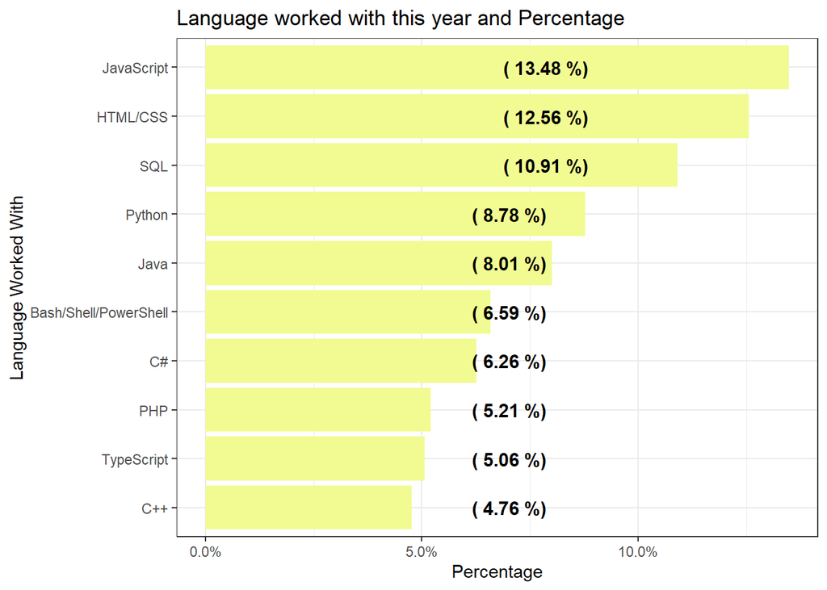

```r
plotPlatformDesire <- function(survey_data,TotalNoofRows) {
  survey_data %>%
    filter(!is.na(LanguageWorkedWith)) %>%
    select(LanguageWorkedWith) %>%
    mutate(LanguageWorkedWith = str_split(LanguageWorkedWith, pattern = ";")) %>%
    unnest(LanguageWorkedWith) %>%
    group_by(LanguageWorkedWith) %>%
    summarise(Count = n()) %>%
    arrange(desc(Count)) %>%
    ungroup() %>%
    mutate(TotalCount =  sum(Count)) %>%
    mutate(Count =  Count/TotalCount) %>%
    mutate(LanguageWorkedWith = reorder(LanguageWorkedWith,Count)) %>%
    head(10) %>%

    ggplot(aes(x = LanguageWorkedWith,y = Count)) +
    geom_bar(stat='identity',fill= fillcolor2) +
    geom_text(aes(x = LanguageWorkedWith,y = .01, label = paste0("( ",round(Count*100,2)," %)",sep="")),
              hjust= -3, vjust=.5, size = 4, colour = 'black',
              fontface = 'bold') +
    scale_y_continuous(labels = scales::percent_format()) +
    labs(x = 'Language Worked With',
         y='Percentage',
         title = 'Language worked with this year and Percentage') +
    coord_flip() +
    theme_bw()
}

plotPlatformDesire(survey_data,TotalNoofRows)
```

#Salary analysis by developer type worldwide

```r
salary_by_developer_type_worldwide<- survey_data %>%
  filter(!is.na(DevType)) %>%
  select(DevType, ConvertedComp) %>%
  mutate(DevType = str_split(DevType, pattern = ";")) %>%
  unnest(DevType) %>%
  group_by(DevType) %>%
  summarise(median_salary = median(ConvertedComp, na.rm = TRUE)) %>%
  arrange(desc(median_salary)) %>%
  ungroup() %>%
  mutate(DevType = reorder(DevType, median_salary))
```

```r
salary_by_developer_type_worldwide_plot <- ggplot(data = salary_by_developer_type_worldwide,
                                                  aes(x = DevType, y = median_salary))+
  geom_bar(stat = 'identity', fill = fillcolor2)+
  geom_text(aes(x = DevType, y = 1, label = paste0("( ",round(median_salary/1e3)," K)",sep="")),
            hjust = -3, vjust = 0.5, size = 3, color = 'black', fontface = 'bold')+
  labs(
    x = 'DevType',
    y = 'median_salary',
    title = "Median Salary according to developer type Worldwide"
  )+
  coord_flip()+
  theme_classic()

survey_schema %>%
  filter(Column == "YearsCodePro") %>%
  select(QuestionText)
```

```
##                                                                                      QuestionText
## 1 NOT including education, how many years have you coded professionally (as a part of your work)?
```

## Salary Analysis Dev Types - Years of experiences

## with yearcodepro

```r
salary_by_dev_type <- survey_data %>%
  select(DevType, YearsCodePro, ConvertedComp) %>%
  mutate(DevType = str_split(DevType, pattern = ";")) %>%
  unnest(DevType) %>%
  group_by(DevType, YearsCodePro) %>%
  summarise(median_salary = median(ConvertedComp, na.rm = TRUE)) %>%
  arrange(desc(median_salary)) %>%
  ungroup() %>%
  mutate(YearsCodePro = as.character(YearsCodePro),
         DevType = as.character(DevType)) %>%
  mutate(DevType_YearsCodePro = paste(DevType,YearsCodePro)) %>%
  mutate(DevType_YearsCodePro =str_replace(DevType_YearsCodePro,"NA","")) %>%
  mutate(DevType_YearsCodePro = reorder(DevType_YearsCodePro, median_salary)) %>%
  head(10)
```

# BANGLADESH

```r
#dataframe of bd
bd <-survey_data[survey_data$Country=="Bangladesh",]
```

## Salary analysis by developer type

```r
salary_by_developer_type_Bangladesh <- survey_data %>%
  filter(Country == "Bangladesh") %>%
  filter(!is.na(DevType)) %>%
  select(DevType, ConvertedComp) %>%
  mutate(DevType = str_split(DevType, pattern = ";")) %>%
  unnest(DevType) %>%
  group_by(DevType) %>%
  summarise(median_salary = median(ConvertedComp, na.rm = TRUE)) %>%
  arrange(desc(median_salary)) %>%
  ungroup() %>%
  mutate(DevType = reorder(DevType, median_salary))
```

```r
salary_by_developer_type_Bangladesh_plot <- ggplot(data = salary_by_developer_type_Bangladesh,
                                                   aes(x = DevType, y = median_salary))+
  geom_bar(stat = 'identity', fill = fillcolor2)+
  geom_text(aes(x = DevType, y = 1, label = paste0("( ",round(median_salary/1e3)," K)",sep="")),
            hjust = -3, vjust = 0.5, size = 3, color = 'black', fontface = 'bold')+
  labs(
    x = 'DevType',
    y = 'median_salary',
    title = "Median Salary according to developer type in Bangladesh"
  )+
  coord_flip()+
  theme_classic()
```

## developer by profession

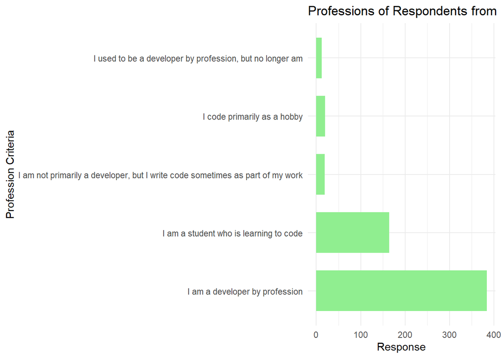

```r
profession.bd <- bd %>% filter(!is.na(MainBranch))
profession.bd.plot <-ggplot(profession.bd,aes(y=factor(MainBranch)))+  geom_bar(stat="count", width=0.7, fill="LightGreen")+
  labs(title= "Professions of Respondents from Bangladesh",
       y="Profession Criteria",
       x="Response") + theme_minimal()
profession.bd.plot
```

##coding as hobby

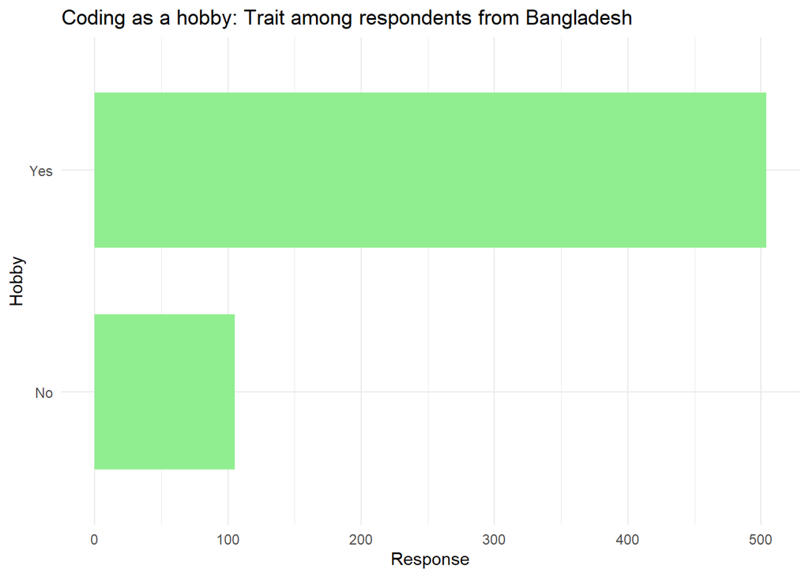

```r
hobby.bd <- bd %>% filter(!is.na(Hobbyist))
hobby.bd.plot <- ggplot(hobby.bd,aes(y=factor(Hobbyist)))+  geom_bar(stat="count", width=0.7, fill="LightGreen")+
  labs(title= "Coding as a hobby: Trait among respondents from Bangladesh",
       y="Hobby",
       x="Response") + theme_minimal()
hobby.bd.plot
```

## employment status

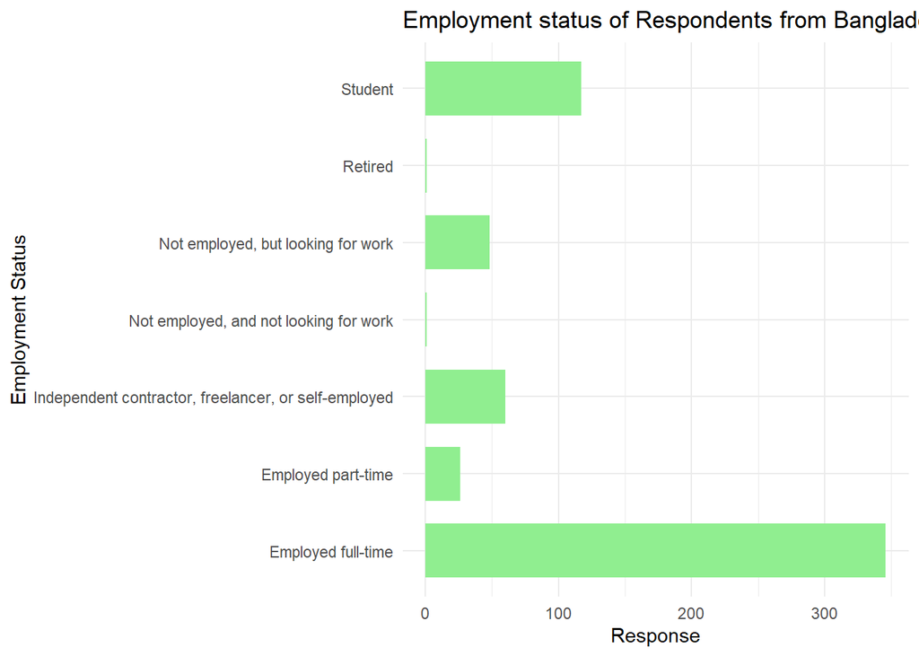

```r
employment.bd <- bd %>% filter(!is.na(Employment))
  employment.bd.plot <-  ggplot(employment.bd,aes(y=factor(Employment)))+  geom_bar(stat="count", width=0.7, fill="LightGreen")+
  labs(title= "Employment status of Respondents from Bangladesh",
       y="Employment Status",
       x="Response") + theme_minimal()
employment.bd.plot
```

## formal education

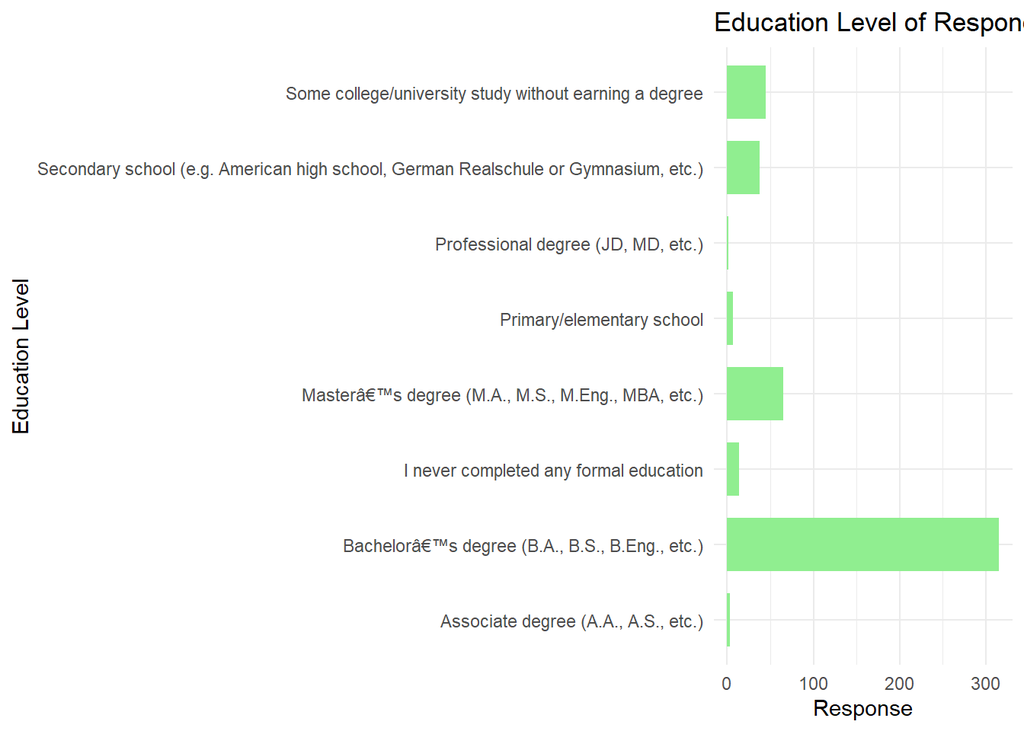

```r
edulevel.bd <- bd %>% filter(!is.na(EdLevel))
edulevel.bd.plot <- ggplot(edulevel.bd,aes(y=factor(EdLevel)))+  geom_bar(stat="count", width=0.7, fill="LightGreen")+
  labs(title= "Education Level of Respondents from Bangladesh",
       y="Education Level",
       x="Response") + theme_minimal()
edulevel.bd.plot
```

## undergrad

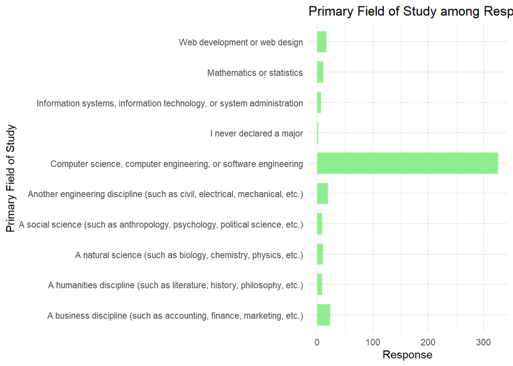

```r
undergrad.bd <- bd %>% filter(!is.na(UndergradMajor))
undergrad.bd.plot <- ggplot(undergrad.bd,aes(y=factor(UndergradMajor)))+  geom_bar(stat="count", width=0.7, fill="LightGreen")+
  labs(title= "Primary Field of Study among Respondents from Bangladesh",
       y="Primary Field of Study",
       x="Response") + theme_minimal()
undergrad.bd.plot
```

##importance of formal education in the eyes of Respondents

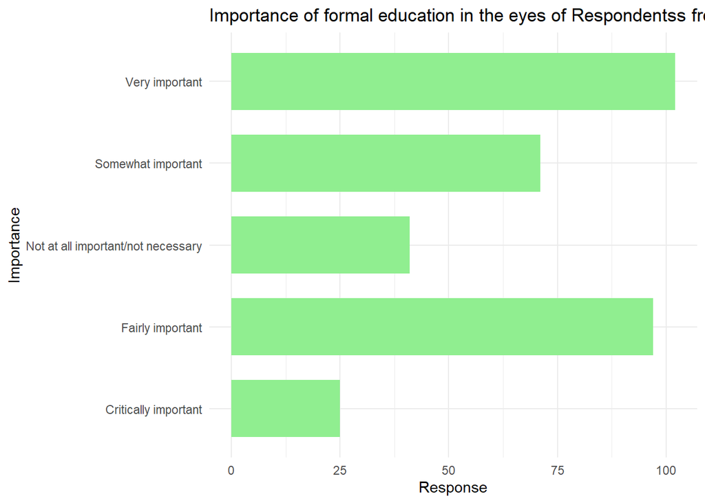

```r
importanceofedu.bd  <- bd %>% filter(!is.na(NEWEdImpt))
importanceofedu.bd.plot<- ggplot(importanceofedu.bd,aes(y=factor(NEWEdImpt)))+  geom_bar(stat="count", width=0.7, fill="LightGreen")+
  labs(title= "Importance of formal education in the eyes of Respondentss from Bangladesh",
       y="Importance",
       x="Response") + theme_minimal()
importanceofedu.bd.plot
```

##Age of responder during first code

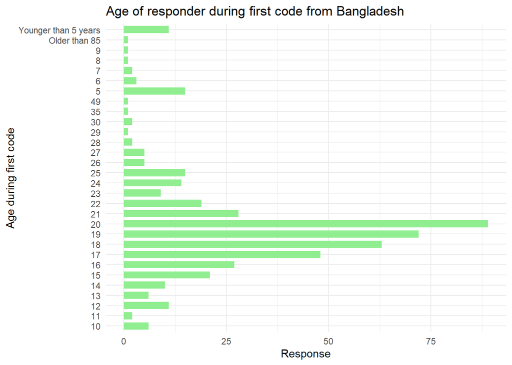

```r
age.bd<- bd %>% filter(!is.na(Age1stCode))
age.bd.plot <- ggplot(age.bd,aes(y=Age1stCode))+  geom_bar(stat="Count", width=0.7, fill="LightGreen")+

  labs(title= "Age of responder during first code from Bangladesh",
       y="Age during first code",
       x="Response") + theme_minimal()
age.bd.plot
```

##total years of coding

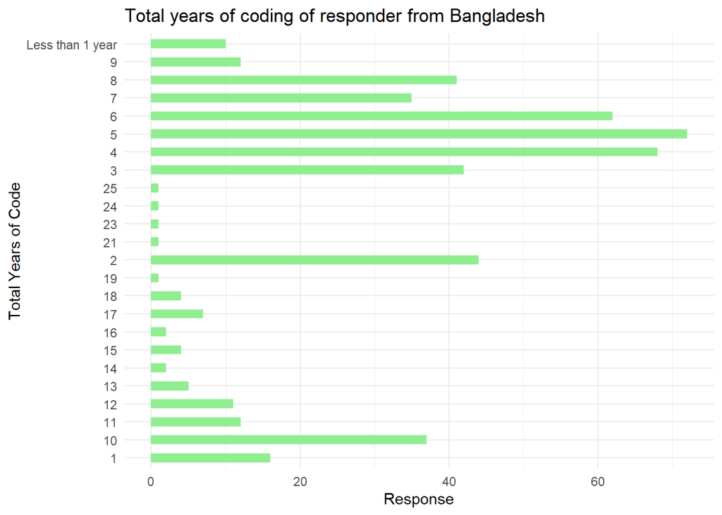

```r
YearsCode.bd <- bd  %>% filter(!is.na(YearsCode))

YearsOfCoding.bd.plot <- ggplot(YearsCode.bd,aes(y=YearsCode))+  geom_bar(stat="Count", width=.5, fill="LightGreen")+
  labs(title= "Total years of coding of responder from Bangladesh",
       y="Total Years of Code",
       x="Response") + theme_minimal()
YearsOfCoding.bd.plot
```

##coding professionally as part of job

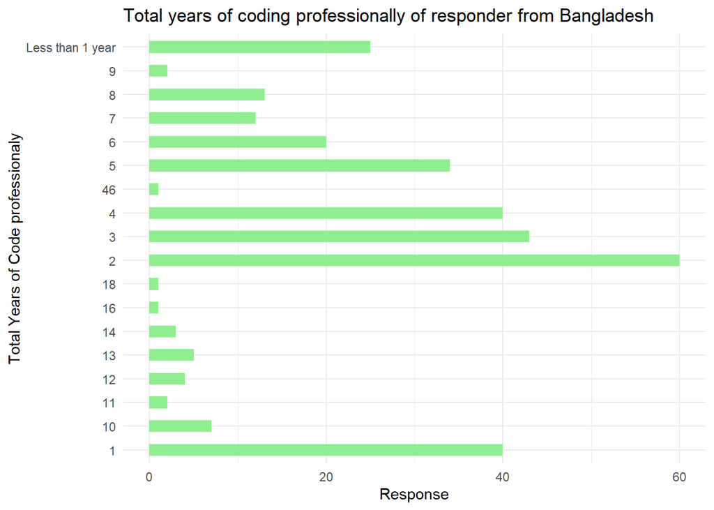

```r
YearsCodeProf.bd <- bd  %>% filter(!is.na(YearsCodePro))

YearsOfCodingprof.bd.plot <- ggplot(YearsCodeProf.bd,aes(y=YearsCodePro))+  geom_bar(stat="Count", width=.5, fill="LightGreen")+
  labs(title= "Total years of coding professionally of responder from Bangladesh",
       y="Total Years of Code professionaly",
       x="Response") + theme_minimal()
YearsOfCodingprof.bd.plot
```

##job satisfaction

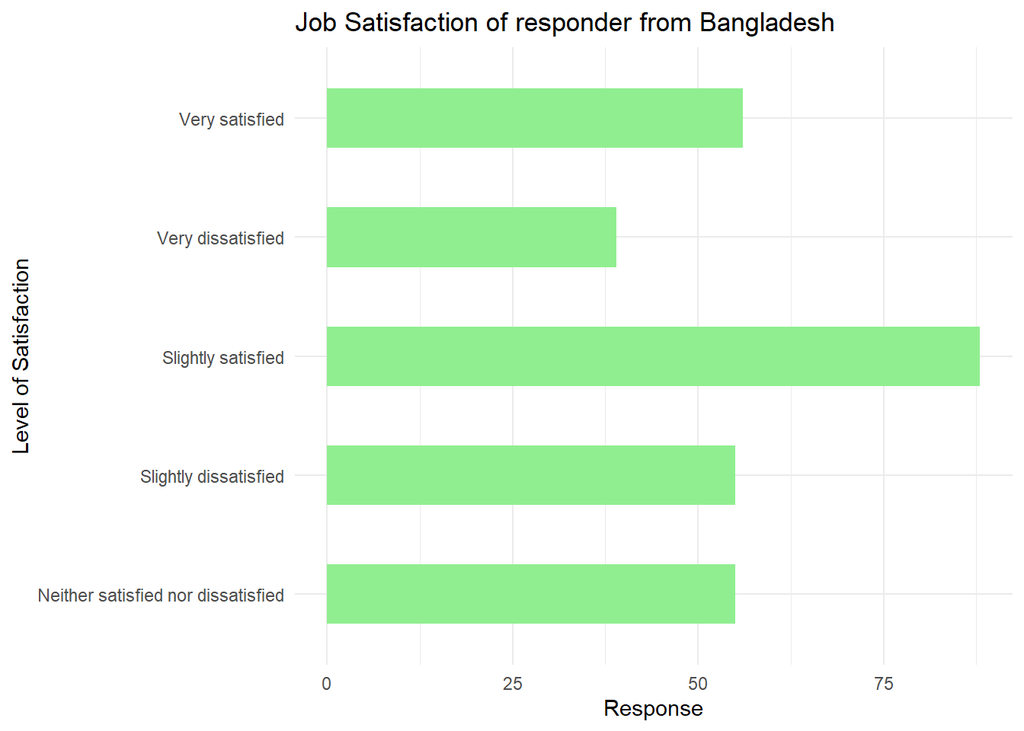

```r
Jobsatifsaction.bd <- bd  %>% filter(!is.na(JobSat))

Jobsatifsaction.bd.plot <- ggplot(Jobsatifsaction.bd,aes(y=JobSat))+  geom_bar(stat="Count", width=.5, fill="LightGreen")+
  labs(title= "Job Satisfaction of responder from Bangladesh",
       y="Level of Satisfaction",
       x="Response") + theme_minimal()
Jobsatifsaction.bd.plot
```

##Organization size of the responders employing company

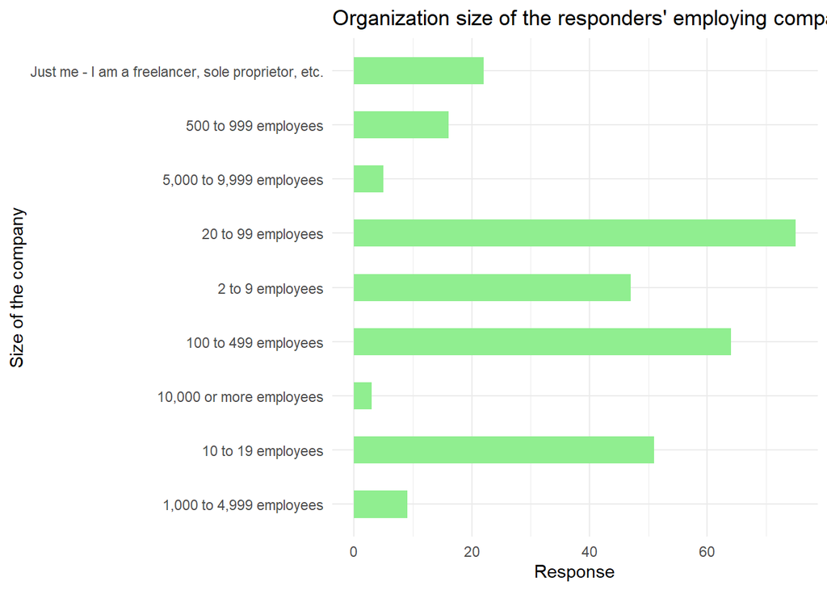

```r
OrgSize.bd <- bd  %>% filter(!is.na(OrgSize))
OrgSize.bd.plot <- ggplot(OrgSize.bd,aes(y=OrgSize))+  geom_bar(stat="Count", width=.5, fill="LightGreen")+
  labs(title= "Organization size of the responders' employing company from Bangladesh",
       y="Size of the company",
       x="Response") + theme_minimal()
OrgSize.bd.plot
```

##currency used by responder

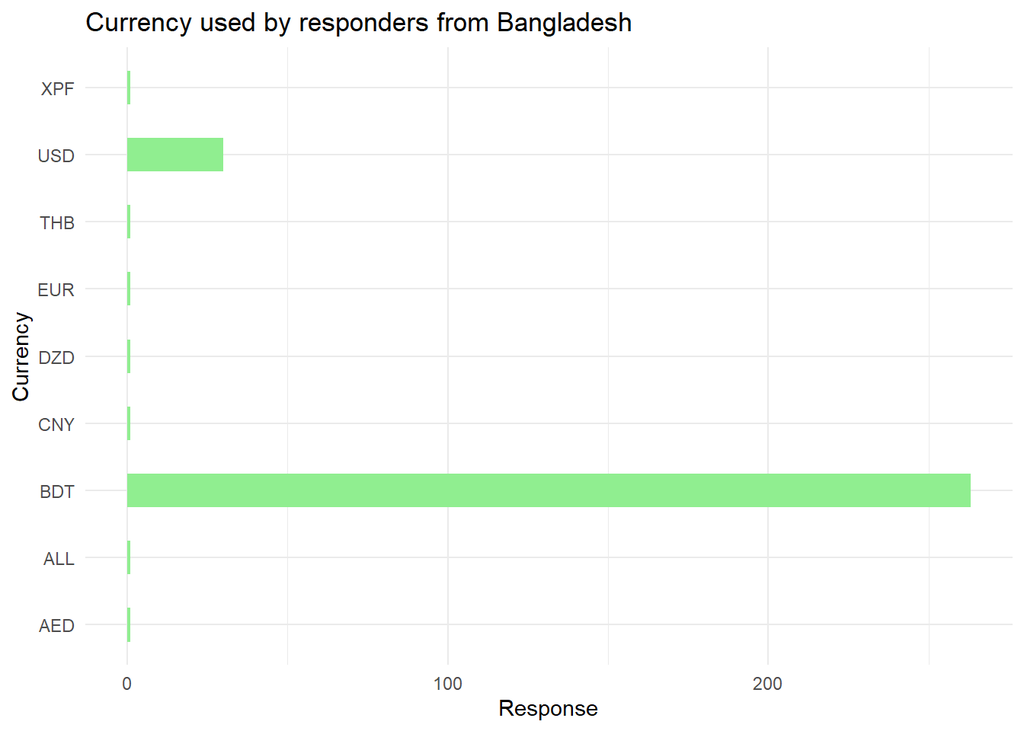

```r
Currency.bd <- bd  %>% filter(!is.na(CurrencySymbol))
Currency.bd.plot <- ggplot(Currency.bd,aes(y=CurrencySymbol))+  geom_bar(stat="Count", width=.5, fill="LightGreen")+
  labs(title= "Currency used by responders from Bangladesh",
       y="Currency",
       x="Response") + theme_minimal()
Currency.bd.plot
```

##Work hours per week of responders from Bangladesh

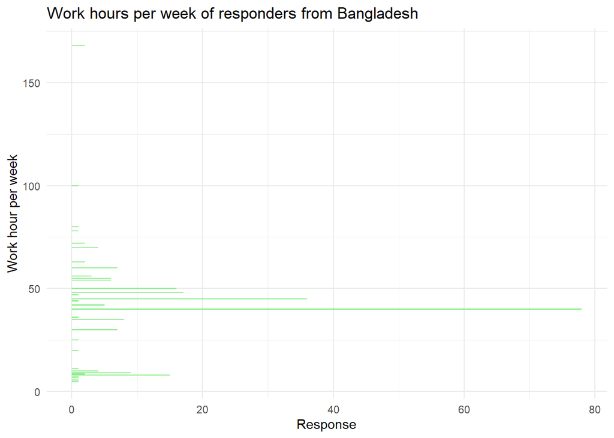

```r
WorkWeekHrs.bd <- bd  %>% filter(!is.na(WorkWeekHrs))
WorkWeekHrs.bd.plot <- ggplot(WorkWeekHrs.bd,aes(y=WorkWeekHrs))+  geom_bar(stat="Count", width=.5, fill="LightGreen")+
  labs(title= "Work hours per week of responders from Bangladesh",
       y="Work hour per week",
       x="Response") + theme_minimal()
WorkWeekHrs.bd.plot
```

##Overtime dony by responders from Bangladesh

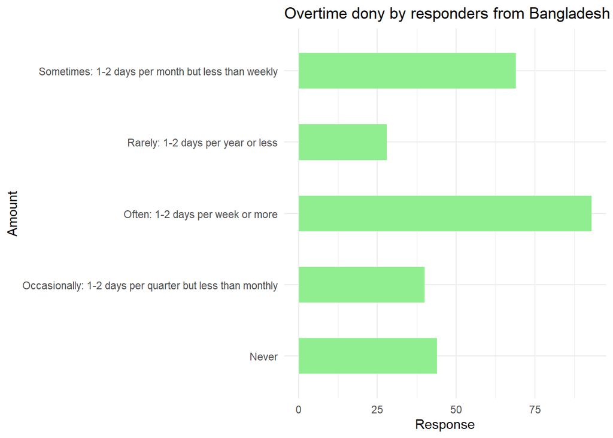

```r
overtime.bd <- bd  %>% filter(!is.na(NEWOvertime))
overtime.bd.plot <- ggplot(overtime.bd,aes(y=NEWOvertime))+  geom_bar(stat="Count", width=.5, fill="LightGreen")+
  labs(title= "Overtime dony by responders from Bangladesh",
       y="Amount",
       x="Response") + theme_minimal()
overtime.bd.plot
```

##Onboarding process evaluation by responders

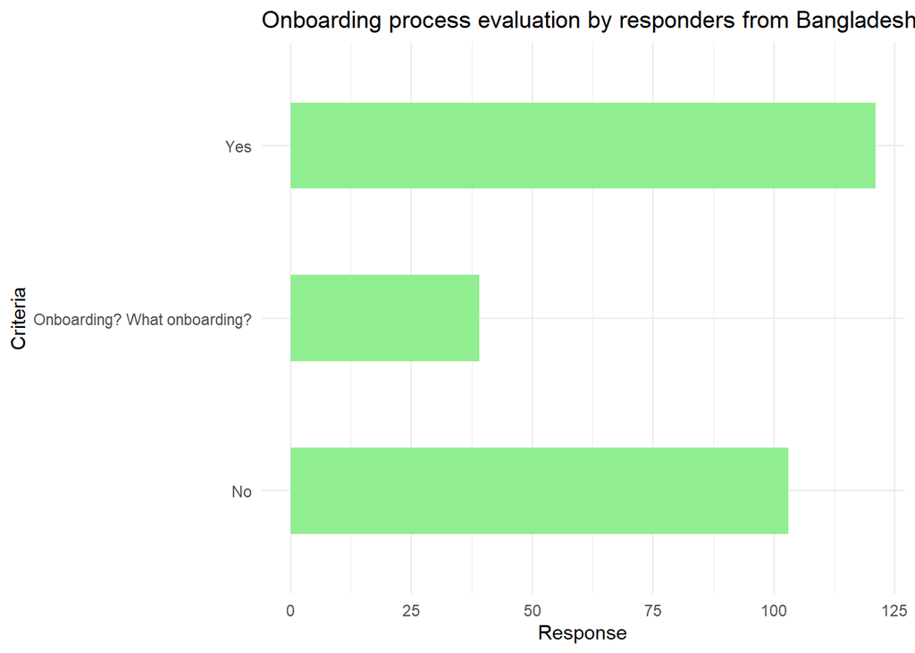

```r
onboarding.bd <- bd  %>% filter(!is.na(NEWOnboardGood))
onboarding.bd.plot <- ggplot(onboarding.bd,aes(y=NEWOnboardGood))+  geom_bar(stat="Count", width=.5, fill="LightGreen")+
  labs(title= "Onboarding process evaluation by responders from Bangladesh",
       y="Criteria",
       x="Response") + theme_minimal()
onboarding.bd.plot
```

##dedicated DevOps person in responders' company from Bangladesh

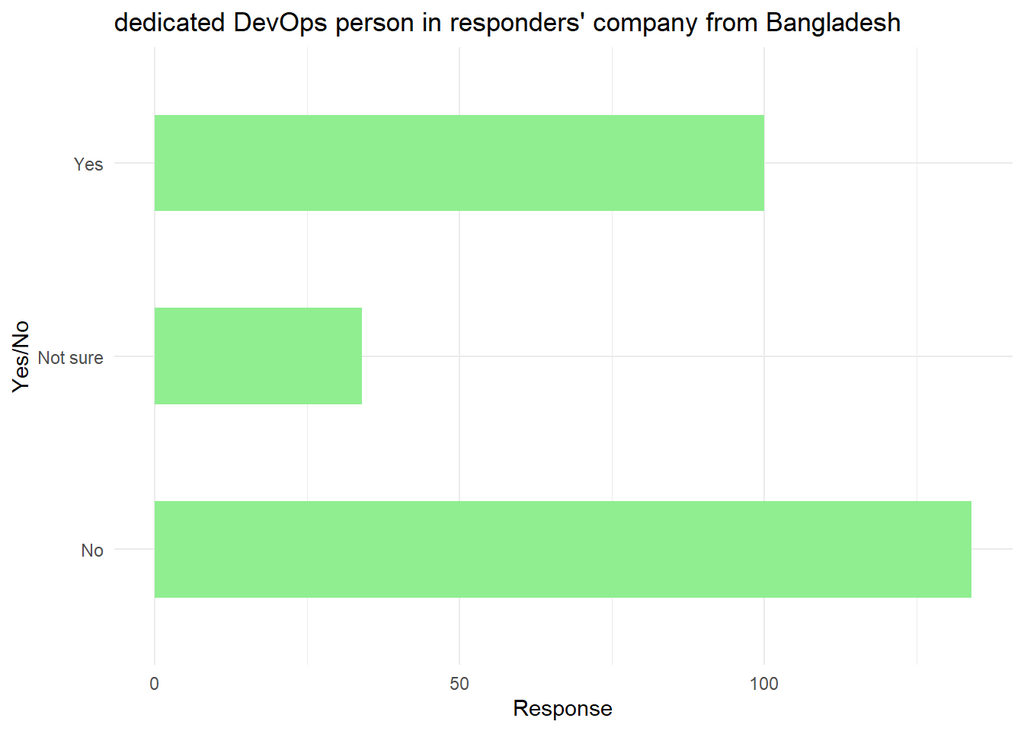

```r
NEWDevOps.bd <- bd  %>% filter(!is.na(NEWDevOps))
NEWDevOps.bd.plot <- ggplot(NEWDevOps.bd,aes(y=NEWDevOps))+  geom_bar(stat="Count", width=.5, fill="LightGreen")+
  labs(title= "dedicated DevOps person in responders' company from Bangladesh",
       y="Yes/No",
       x="Response") + theme_minimal()
NEWDevOps.bd.plot
```

##importance if the practice of DevOps to scaling software development

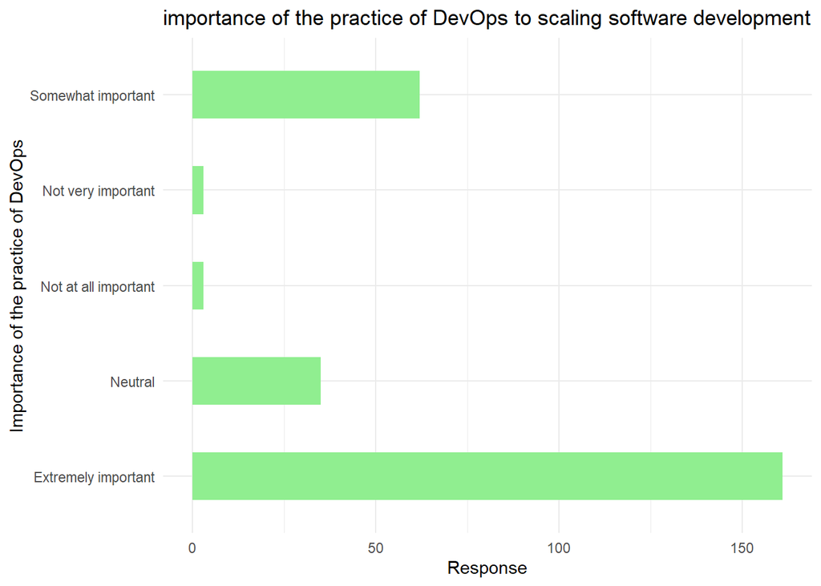

```r
NEWDevOpsimportance.bd <- bd  %>% filter(!is.na(NEWDevOpsImpt))
NEWDevOpsimportance.bd.plot <- ggplot(NEWDevOpsimportance.bd,aes(y=NEWDevOpsImpt))+  geom_bar(stat="Count", width=.5, fill="LightGreen")+
  labs(title= "importance of the practice of DevOps to scaling software development",
       y="Importance of the practice of DevOps",
       x="Response") + theme_minimal()
NEWDevOpsimportance.bd.plot
```

## current job seeking status

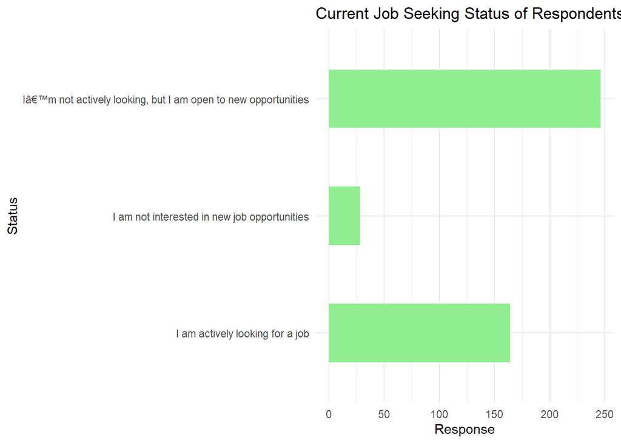

```r
jobseek.bd <- bd  %>% filter(!is.na(JobSeek))
jobseek.bd.plot <- ggplot(jobseek.bd,aes(y=JobSeek))+  geom_bar(stat="Count", width=.5, fill="LightGreen")+
  labs(title= "Current Job Seeking Status of Respondents of Bangladesh",
       y="Status",
       x="Response") + theme_minimal()
jobseek.bd.plot
```

##Frequency of learning new language/framework

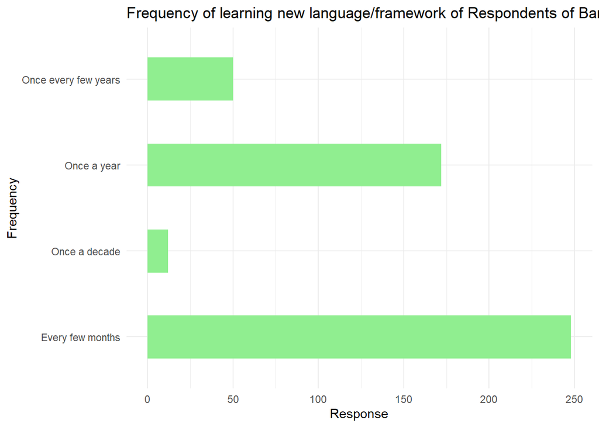

```r
NEWLearn.bd <- bd  %>% filter(!is.na(NEWLearn))
NEWLearn.bd.plot <- ggplot(NEWLearn.bd,aes(y=NEWLearn))+  geom_bar(stat="Count", width=.5, fill="LightGreen")+
  labs(title= "Frequency of learning new language/framework of Respondents of Bangladesh",
       y="Frequency",
       x="Response") + theme_minimal()
NEWLearn.bd.plot
```

##Operating system used by the Respondents

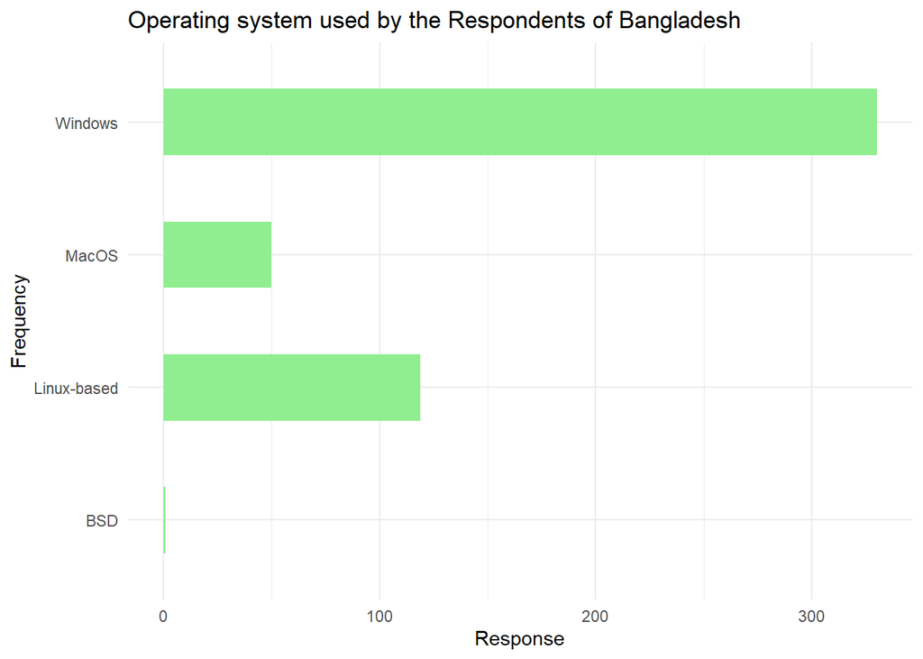

```r
OS.bd<- bd  %>% filter(!is.na(OpSys))
OS.bd.plot <- ggplot(OS.bd,aes(y=OpSys))+  geom_bar(stat="Count", width=.5, fill="LightGreen")+
  labs(title= "Operating system used by the Respondents of Bangladesh",
       y="Frequency",
       x="Response") + theme_minimal()
OS.bd.plot
```

##influence of respondent in organization

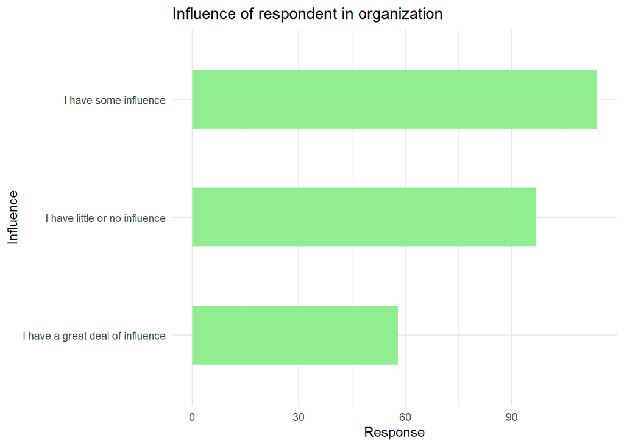

```r
influence.bd<- bd  %>% filter(!is.na(PurchaseWhat))
influence.bd.plot <- ggplot(influence.bd,aes(y=PurchaseWhat))+  geom_bar(stat="Count", width=.5, fill="LightGreen")+
  labs(title= "Influence of respondent in organization",
       y="Influence",
       x="Response") + theme_minimal()
influence.bd.plot
```

##Previously visited link induced response

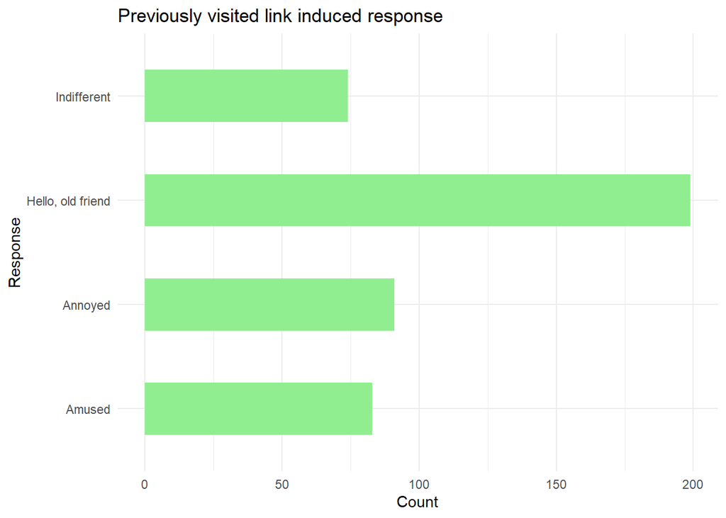

```r
prevVisitLink.bd<- bd  %>% filter(!is.na(NEWPurpleLink))
prevVisitLink.bd.plot <- ggplot(prevVisitLink.bd,aes(y=NEWPurpleLink))+  geom_bar(stat="Count", width=.5, fill="LightGreen")+
  labs(title= "Previously visited link induced response",
       y="Response",
       x="Count") + theme_minimal()
prevVisitLink.bd.plot
```

##frequency of stackoverflow visit

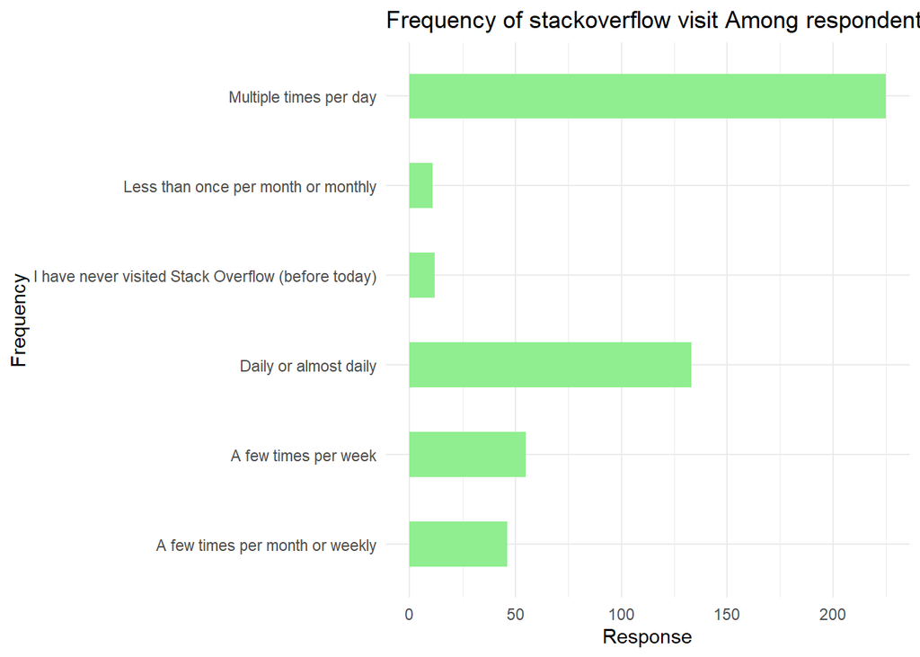

```r
SOVisitFreq.bd<- bd  %>% filter(!is.na(SOVisitFreq))
SOVisitFreq.bd.plot <- ggplot(SOVisitFreq.bd,aes(y=SOVisitFreq))+  geom_bar(stat="Count", width=.5, fill="LightGreen")+
  labs(title= "Frequency of stackoverflow visit Among respondents",
       y="Frequency",
       x="Response") + theme_minimal()
SOVisitFreq.bd.plot
```

##Existence of stackoverflow account

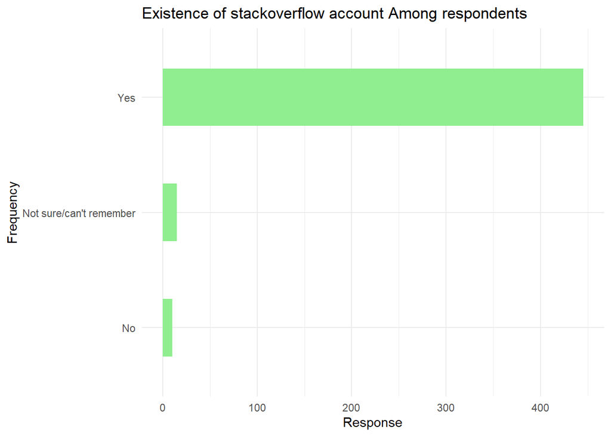

```r
SOAccount.bd<-bd  %>% filter(!is.na(SOAccount))
SOAccount.bd.plot <- ggplot(SOAccount.bd,aes(y=SOAccount))+  geom_bar(stat="Count", width=.5, fill="LightGreen")+
  labs(title= "Existence of stackoverflow account Among respondents",
       y="Frequency",
       x="Response") + theme_minimal()
SOAccount.bd.plot
```

##Frequency of participating in SO Q/A

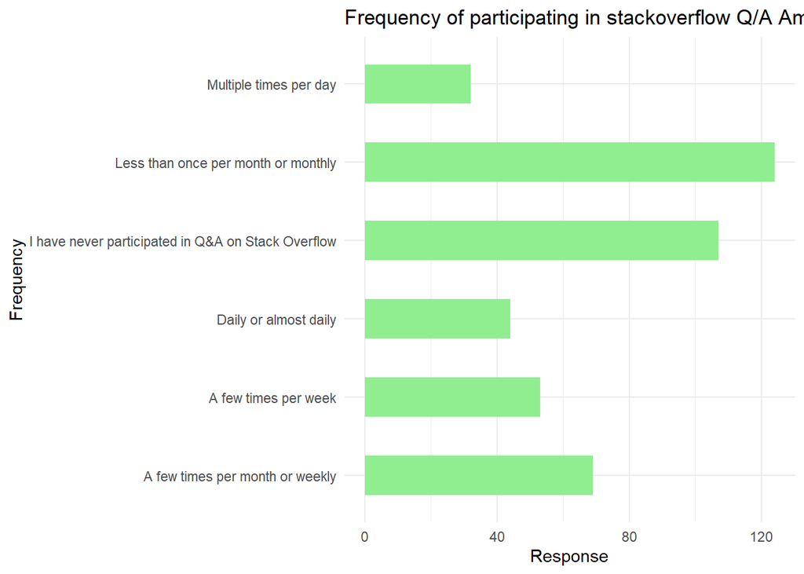

```r
frequencyQA.bd<-bd  %>% filter(!is.na(SOPartFreq))
frequencyQA.bd.plot <- ggplot(frequencyQA.bd,aes(y=SOPartFreq))+  geom_bar(stat="Count", width=.5, fill="LightGreen")+
  labs(title= "Frequency of participating in stackoverflow Q/A Among respondents",
       y="Frequency",
       x="Response") + theme_minimal()
frequencyQA.bd.plot
```